# Micro Capstone

Scott Waugh

Read in excel sheet with data from baseball reference from 1969 to 2021 with about 162 games (excluding 1981, 1994, 1995, and 2020) and removing random rows that show up

```r
baseball = read.table("BaseballCapstoneData.csv", header = TRUE, sep=",")
baseball$X = NULL
baseball$X.1 = NULL
baseball$X.2 = NULL
baseball$X.3 = NULL
baseball$X.4 = NULL
baseball$X.5 = NULL
```

Run the full model looking at response variable y with all the variables

```r
startmodel = lm(W ~ BatAge + RG + R + H + SB + TB + HR + RBI + SB + CS + BB + SO + BA + OBP + SLG + OPS + PAge + RAG + ERA + CG + tSho+ cSho + SV + HA + RA + ER + HRA + BBA + SOA + FIP + WHIP, data = baseball)

summary(startmodel)
```

```
##
## Call:
## lm(formula = W ~ BatAge + RG + R + H + SB + TB + HR + RBI + SB +
##     CS + BB + SO + BA + OBP + SLG + OPS + PAge + RAG + ERA +
##     CG + tSho + cSho + SV + HA + RA + ER + HRA + BBA + SOA +
##     FIP + WHIP, data = baseball)
##
## Residuals:
##     Min      1Q  Median      3Q     Max
## -9.7991 -2.1342 -0.0171  2.0923 10.9872
##
## Coefficients:
##               Estimate Std. Error t value Pr(>|t|)
## (Intercept)  4.052e+00  6.279e+00   0.645  0.51878
## BatAge       1.337e-01  8.149e-02   1.641  0.10101
## RG          -2.925e+01  1.441e+01  -2.030  0.04260 *
## R            2.612e-01  8.988e-02   2.905  0.00373 **
## H           -1.005e-01  1.543e-02  -6.509 1.07e-10 ***
## SB          -3.276e-02  2.437e-02  -1.344  0.17911
## TB          -6.653e-02  5.033e-02  -1.322  0.18640
## HR          -8.210e-02  7.255e-02  -1.132  0.25800
## RBI          3.800e-03  1.285e-02   0.296  0.76743
## CS          -4.009e-02  7.225e-03  -5.548 3.48e-08 ***
## BB          -1.416e-02  6.424e-03  -2.204  0.02771 *
## SO           2.640e-03  1.027e-03   2.570  0.01028 *
## BA           5.011e+02  2.091e+02   2.396  0.01669 *
## OBP         -1.977e+02  1.425e+02  -1.387  0.16565
## SLG         -1.267e+02  1.694e+02  -0.748  0.45478
## OPS          2.852e+02  1.335e+02   2.136  0.03287 *
## PAge         4.387e-02  7.077e-02   0.620  0.53543
## RAG          2.301e+01  1.459e+01   1.577  0.11495
## ERA         -5.224e+00  1.131e+01  -0.462  0.64434
## CG           1.342e-01  1.438e-02   9.336  < 2e-16 ***
## tSho         1.639e-01  3.646e-02   4.494 7.59e-06 ***
## cSho         2.465e-02  5.250e-02   0.470  0.63872
## SV           3.274e-01  1.494e-02  21.922  < 2e-16 ***
## HA           9.418e-02  2.310e-02   4.078 4.82e-05 ***
## RA          -2.012e-01  9.026e-02  -2.229  0.02598 *
## ER           3.997e-02  7.093e-02   0.564  0.57313
## HRA         -2.117e-03  1.090e-02  -0.194  0.84601
## BBA          9.643e-02  2.329e-02   4.140 3.69e-05 ***
## SOA          5.395e-04  1.462e-03   0.369  0.71213
## FIP         -8.661e-01  1.015e+00  -0.853  0.39359
## WHIP        -1.463e+02  3.330e+01  -4.395 1.20e-05 ***
## ---
## Signif. codes:  0 '***' 0.001 '**' 0.01 '*' 0.05 '.' 0.1 ' ' 1
##
## Residual standard error: 3.107 on 1325 degrees of freedom
## Multiple R-squared:  0.9291, Adjusted R-squared:  0.9275
## F-statistic: 578.6 on 30 and 1325 DF,  p-value: < 2.2e-16
```

Run stepwise to find best model

```r
require(MASS)
min_model = lm(W ~ 1, data = baseball)
max_model = formula(W ~ BatAge + RG + R + H + SB + TB + HR + RBI + SB + CS + BB + SO + BA + OBP + SLG + OPS + PAge + RAG + ERA + CG + tSho+ cSho + SV + HA + RA + ER + HRA + BBA + SOA + FIP + WHIP, data = baseball)
best_model = step(min_model, direction = "both", scope = max_model)
```

```
## Start:  AIC=6633.56
## W ~ 1
##
##          Df Sum of Sq    RSS    AIC
## + WHIP    1     65134 115247 6028.1
## + RAG     1     58997 121384 6098.4
## + RA      1     57263 123118 6117.7
## + RG      1     52723 127658 6166.8
## + R       1     52385 127995 6170.4
## + ERA     1     51985 128396 6174.6
## + OBP     1     50440 129941 6190.8
## + SV      1     49823 130558 6197.2
## + RBI     1     49805 130576 6197.4
## + ER      1     48400 131981 6211.9
## + OPS     1     43557 136824 6260.8
## + HA      1     36560 143821 6328.4
## + tSho    1     36162 144219 6332.2
## + BBA     1     34699 145682 6345.9
## + SLG     1     32998 147383 6361.6
## + BA      1     30265 150116 6386.5
## + BB      1     29342 151038 6394.8
## + FIP     1     28120 152261 6405.8
## + H       1     25698 154682 6427.1
## + PAge    1     19945 160436 6476.7
## + HR      1     18277 162104 6490.7
## + BatAge  1     16343 164038 6506.8
## + SB      1      9107 171273 6565.3
## + HRA     1      8611 171770 6569.2
## + cSho    1      6139 174242 6588.6
## + SOA     1      5825 174556 6591.1
## + CG      1      1039 179342 6627.7
## + SO      1       680 179701 6630.4
## + CS      1       572 179808 6631.2
## + TB      1       279 180102 6633.5
## <none>                180381 6633.6
##
## Step:  AIC=6028.09
## W ~ WHIP
##
##          Df Sum of Sq    RSS    AIC
```

[output cut: 673 more lines]

```
## - BB      1      46.1 12964 3095.4
## - FIP     1      54.9 12973 3096.3
## - BatAge  1      67.6 12986 3097.7
## - SO      1      95.8 13014 3100.6
## - tSho    1     310.9 13229 3122.8
## - CS      1     335.6 13254 3125.4
## - BA      1     611.1 13530 3153.3
## - H       1    1218.4 14137 3212.8
## - CG      1    1554.6 14473 3244.7
## - HA      1    1651.5 14570 3253.7
## - BBA     1    1692.3 14611 3257.5
## - WHIP    1    1825.7 14744 3269.8
## - RAG     1    2228.6 15147 3306.4
## - SV      1    4971.8 17890 3532.1
## - R       1    5480.5 18399 3570.1
```

run new stepwise model

```r
stepwiseModel = lm(W ~ WHIP + R + RAG + SV + CG + tSho + OBP + BatAge + HA + BBA +
    HR + H + BA + CS + SO + BB + FIP, data = baseball)

summary(stepwiseModel)
```

```
##
## Call:
## lm(formula = W ~ WHIP + R + RAG + SV + CG + tSho + OBP + BatAge +
##     HA + BBA + HR + H + BA + CS + SO + BB + FIP, data = baseball)
##
## Residuals:
##     Min      1Q  Median      3Q     Max
## -9.8808 -2.1016 -0.0087  2.0919 10.8046
##
## Coefficients:
##               Estimate Std. Error t value Pr(>|t|)
## (Intercept)  5.126e+00  5.811e+00   0.882  0.37784
## WHIP        -1.579e+02  1.148e+01 -13.751  < 2e-16 ***
## R            8.257e-02  3.466e-03  23.825  < 2e-16 ***
## RAG         -8.544e+00  5.624e-01 -15.193  < 2e-16 ***
## SV           3.288e-01  1.449e-02  22.693  < 2e-16 ***
## CG           1.348e-01  1.062e-02  12.689  < 2e-16 ***
## tSho         1.677e-01  2.955e-02   5.675 1.70e-08 ***
## OBP          8.544e+01  5.501e+01   1.553  0.12062
## BatAge       1.899e-01  7.173e-02   2.647  0.00822 **
## HA           1.017e-01  7.777e-03  13.079  < 2e-16 ***
## BBA          1.046e-01  7.899e-03  13.239  < 2e-16 ***
## HR           6.523e-03  4.491e-03   1.452  0.14663
## H           -1.147e-01  1.021e-02 -11.233  < 2e-16 ***
## BA           7.370e+02  9.263e+01   7.956 3.76e-15 ***
## CS          -4.022e-02  6.822e-03  -5.896 4.71e-09 ***
## SO           2.737e-03  8.690e-04   3.150  0.00167 **
## BB          -1.337e-02  6.121e-03  -2.185  0.02907 *
## FIP         -9.949e-01  4.173e-01  -2.384  0.01725 *
## ---
## Signif. codes:  0 '***' 0.001 '**' 0.01 '*' 0.05 '.' 0.1 ' ' 1
##
## Residual standard error: 3.107 on 1338 degrees of freedom
## Multiple R-squared:  0.9284, Adjusted R-squared:  0.9275
## F-statistic:  1020 on 17 and 1338 DF,  p-value: < 2.2e-16
```

run test for collinearity

```r
require(regclass)
stepwiseModel = lm(W ~ WHIP + R + RAG + SV + CG + tSho + OBP + BatAge + HA + BBA +
    HR + H + BA + CS + SO + BB + FIP, data = baseball)
VIF(stepwiseModel)
```

```
##       WHIP          R        RAG         SV         CG       tSho        OBP
## 157.956450  13.144543  13.928407   2.342199   4.182153   2.081504  85.882095
##     BatAge         HA        BBA         HR          H         BA         CS
##   1.370887  73.997832  38.774936   5.031586 112.132710 186.191068   1.983313
##         SO         BB        FIP
##   4.289048  25.542655   5.579742
```

make small data frame for correlation matrix

```r
baseballNew <- baseball[, colnames(baseball)[c(3,7,9,10,13,16,17,18,19,20,24,26,27,29,30,34,36,37)]]
```

run correlation matrix

```r
round(cor(baseballNew),3)
```

```
##             W BatAge      R      H     HR     CS     BB     SO     BA    OBP
## W       1.000  0.301  0.539  0.377  0.318 -0.056  0.403 -0.061  0.410  0.529
## BatAge  0.301  1.000  0.331  0.265  0.279 -0.194  0.235 -0.015  0.270  0.340
## R       0.539  0.331  1.000  0.770  0.716 -0.206  0.514  0.131  0.757  0.860
## H       0.377  0.265  0.770  1.000  0.313 -0.028  0.180 -0.227  0.979  0.802
## HR      0.318  0.279  0.716  0.313  1.000 -0.473  0.291  0.543  0.274  0.417
## CS     -0.056 -0.194 -0.206 -0.028 -0.473  1.000 -0.007 -0.491  0.027 -0.035
## BB      0.403  0.235  0.514  0.180  0.291 -0.007  1.000  0.001  0.201  0.688
## SO     -0.061 -0.015  0.131 -0.227  0.543 -0.491  0.001  1.000 -0.295 -0.143
## BA      0.410  0.270  0.757  0.979  0.274  0.027  0.201 -0.295  1.000  0.835
## OBP     0.529  0.340  0.860  0.802  0.417 -0.035  0.688 -0.143  0.835  1.000
## RAG    -0.572 -0.017  0.297  0.271  0.315 -0.124  0.006  0.207  0.225  0.185
## CG      0.076 -0.209 -0.261 -0.092 -0.455  0.388  0.047 -0.677 -0.037 -0.064
## tSho    0.448  0.031 -0.183 -0.169 -0.196  0.012 -0.005 -0.118 -0.134 -0.104
## SV      0.526  0.258  0.294  0.166  0.304 -0.130  0.108  0.252  0.167  0.213
## HA     -0.450  0.022  0.259  0.388  0.124  0.013  0.003 -0.056  0.342  0.239
## BBA    -0.439 -0.144  0.010  0.022  0.014  0.061  0.063  0.006 -0.006  0.023
## FIP    -0.395  0.064  0.395  0.284  0.452 -0.199  0.037  0.325  0.242  0.235
## WHIP   -0.601 -0.069  0.166  0.249  0.099  0.013  0.001 -0.024  0.223  0.160
##           RAG     CG   tSho     SV     HA    BBA    FIP   WHIP
## W      -0.572  0.076  0.448  0.526 -0.450 -0.439 -0.395 -0.601
## BatAge -0.017 -0.209  0.031  0.258  0.022 -0.144  0.064 -0.069
## R       0.297 -0.261 -0.183  0.294  0.259  0.010  0.395  0.166
## H       0.271 -0.092 -0.169  0.166  0.388  0.022  0.284  0.249
## HR      0.315 -0.455 -0.196  0.304  0.124  0.014  0.452  0.099
## CS     -0.124  0.388  0.012 -0.130  0.013  0.061 -0.199  0.013
## BB      0.006  0.047 -0.005  0.108  0.003  0.063  0.037  0.001
## SO      0.207 -0.677 -0.118  0.252 -0.056  0.006  0.325 -0.024
## BA      0.225 -0.037 -0.134  0.167  0.342 -0.006  0.242  0.223
## OBP     0.185 -0.064 -0.104  0.213  0.239  0.023  0.235  0.160
## RAG     1.000 -0.357 -0.694 -0.203  0.819  0.537  0.865  0.895
## CG     -0.357  1.000  0.313 -0.524 -0.181 -0.067 -0.489 -0.172
## tSho   -0.694  0.313  1.000  0.077 -0.600 -0.395 -0.623 -0.651
## SV     -0.203 -0.524  0.077  1.000 -0.174 -0.248 -0.032 -0.279
## HA      0.819 -0.181 -0.600 -0.174  1.000  0.267  0.638  0.852
## BBA     0.537 -0.067 -0.395 -0.248  0.267  1.000  0.501  0.706
## FIP     0.865 -0.489 -0.623 -0.032  0.638  0.501  1.000  0.744
## WHIP    0.895 -0.172 -0.651 -0.279  0.852  0.706  0.744  1.000
```

Model after removing collinerarity

```r
require(regclass)
modelfinal = lm(W ~ WHIP + SV + tSho + OBP + BatAge +
    HR + CS + SO + BB + FIP, data = baseball)
VIF(modelfinal)
```

```
##     WHIP       SV     tSho      OBP   BatAge       HR       CS       SO
## 3.553551 1.391125 1.916321 3.153331 1.271202 2.648083 1.518892 2.473281
##       BB      FIP
## 2.153899 3.963699
```

```r
summary(modelfinal)
```

```
##
## Call:
## lm(formula = W ~ WHIP + SV + tSho + OBP + BatAge + HR + CS +
##     SO + BB + FIP, data = baseball)
##
## Residuals:
##      Min       1Q   Median       3Q      Max
## -13.7278  -2.9637  -0.0434   3.0229  16.4988
##
## Coefficients:
##               Estimate Std. Error t value Pr(>|t|)
## (Intercept)  25.711585   5.391586   4.769 2.05e-06 ***
## WHIP        -51.694825   2.452699 -21.077  < 2e-16 ***
## SV            0.316476   0.015909  19.893  < 2e-16 ***
## tSho          0.366377   0.040388   9.071  < 2e-16 ***
## OBP         400.913979  15.016133  26.699  < 2e-16 ***
## BatAge       -0.164544   0.098400  -1.672   0.0947 .
## HR            0.079719   0.004641  17.176  < 2e-16 ***
## CS            0.018947   0.008504   2.228   0.0260 *
## SO           -0.007316   0.000940  -7.783 1.41e-14 ***
## BB           -0.005647   0.002532  -2.230   0.0259 *
## FIP          -4.733624   0.500983  -9.449  < 2e-16 ***
## ---
## Signif. codes:  0 '***' 0.001 '**' 0.01 '*' 0.05 '.' 0.1 ' ' 1
##
## Residual standard error: 4.426 on 1345 degrees of freedom
## Multiple R-squared:  0.8539, Adjusted R-squared:  0.8528
## F-statistic: 786.1 on 10 and 1345 DF,  p-value: < 2.2e-16
```

remove batters age since not significant

```r
modelfinal = lm(W ~ WHIP + SV + tSho + OBP +
    HR + CS + SO + BB + FIP, data = baseball)
summary(modelfinal)
```

```
##
## Call:
## lm(formula = W ~ WHIP + SV + tSho + OBP + HR + CS + SO + BB +
##     FIP, data = baseball)
##
## Residuals:
##     Min      1Q  Median      3Q     Max
## -13.708  -2.999  -0.073   3.036  16.567
##
## Coefficients:
##               Estimate Std. Error t value Pr(>|t|)
## (Intercept)  2.155e+01  4.785e+00   4.503 7.28e-06 ***
## WHIP        -5.134e+01  2.445e+00 -20.997  < 2e-16 ***
## SV           3.120e-01  1.569e-02  19.880  < 2e-16 ***
## tSho         3.651e-01  4.041e-02   9.036  < 2e-16 ***
## OBP          3.987e+02  1.497e+01  26.639  < 2e-16 ***
## HR           7.887e-02  4.616e-03  17.085  < 2e-16 ***
## CS           2.145e-02  8.377e-03   2.561   0.0106 *
## SO          -7.020e-03  9.239e-04  -7.599 5.58e-14 ***
## BB          -5.864e-03  2.530e-03  -2.317   0.0206 *
## FIP         -4.795e+00  5.000e-01  -9.591  < 2e-16 ***
## ---
## Signif. codes:  0 '***' 0.001 '**' 0.01 '*' 0.05 '.' 0.1 ' ' 1
##
## Residual standard error: 4.429 on 1346 degrees of freedom
## Multiple R-squared:  0.8536, Adjusted R-squared:  0.8526
## F-statistic:   872 on 9 and 1346 DF,  p-value: < 2.2e-16
```

predict wins with formula

```r
baseball$Pred = predict(modelfinal, baseball)
```

calculate residuals and plot

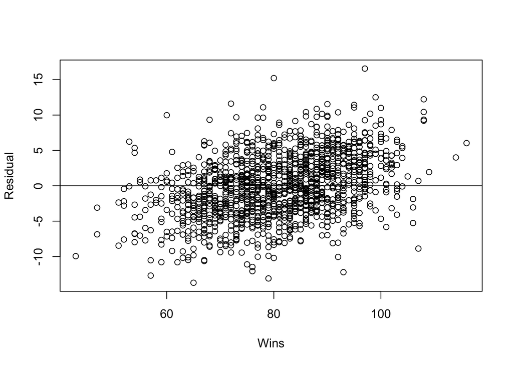

```r
baseball$Residuals = residuals(modelfinal)
plot(baseball$W, baseball$Residuals, xlab = "Wins", ylab = "Residual")
abline(a=0, b=0)
```

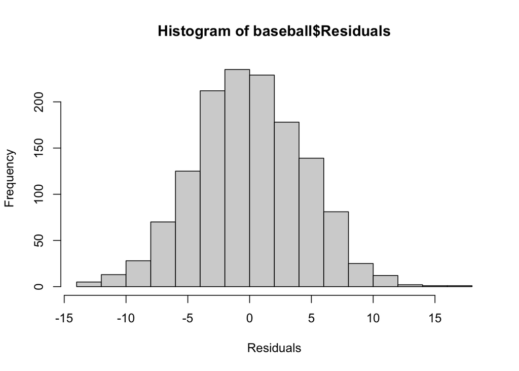

```r
hist(baseball$Residuals, xlab = "Residuals")
```

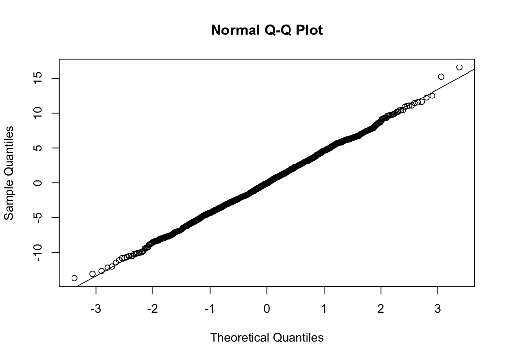

```r
qqnorm(baseball$Residuals)
qqline(baseball$Residuals)
```

Start over using 2011-2021 excluding 2020 and see if there is any difference

Run the full model looking at response variable y with all the variables

[output not shown]

Run stepwise to find best model

```r
require(MASS)
min_model = lm(W ~ 1, data = baseball10years)
max_model = formula(W ~ BatAge + RG + R + H + SB + TB + HR + RBI + SB + CS + BB + SO + BA + OBP + SLG + OPS + PAge + RAG + ERA + CG + tSho+ cSho + SV + HA + RA + ER + HRA + BBA + SOA + FIP + WHIP, data = baseball10years)
best_model = step(min_model, direction = "both", scope = max_model)
```

```
## Start:  AIC=1504.82
## W ~ 1
##
##          Df Sum of Sq   RSS    AIC
## + WHIP    1   25769.5 19175 1251.3
## + RAG     1   24328.3 20617 1273.0
## + RA      1   24272.7 20672 1273.8
## + ERA     1   24027.3 20918 1277.4
## + ER      1   23542.8 21402 1284.2
## + HA      1   19494.7 25450 1336.2
## + SV      1   19224.5 25720 1339.4
## + FIP     1   17230.5 27714 1361.8
## + OBP     1   17203.6 27741 1362.1
## + R       1   15949.2 28996 1375.3
## + RG      1   15866.2 29079 1376.2
## + RBI     1   15730.4 29215 1377.6
## + OPS     1   14809.7 30135 1386.9
## + tSho    1   13896.9 31048 1395.8
## + SLG     1   11545.7 33399 1417.8
## + BB      1   11169.6 33775 1421.1
## + BBA     1    9712.8 35232 1433.8
## + SOA     1    9338.7 35606 1437.0
## + HR      1    7003.0 37942 1456.0
## + BA      1    6551.5 38393 1459.6
## + HRA     1    6079.5 38865 1463.2
## + PAge    1    5495.6 39449 1467.7
## + H       1    5235.9 39709 1469.7
## + SB      1    3941.2 41004 1479.3
## + BatAge  1    3251.3 41694 1484.3
## + CG      1    1703.7 43241 1495.2
## + cSho    1    1698.2 43247 1495.3
## + CS      1    1417.1 43528 1497.2
## + SO      1    1249.4 43696 1498.4
## + TB      1     685.8 44259 1502.2
## <none>                44945 1504.8
##
## Step:  AIC=1251.28
## W ~ WHIP
##
##          Df Sum of Sq   RSS    AIC
```

[output cut: 487 more lines]

```
## + FIP     1      0.92 2531.1 671.79
## + RA      1      0.55 2531.5 671.84
## - HRA     1     41.82 2573.9 672.82
## - tSho    1     63.93 2596.0 675.38
## - BB      1    151.01 2683.1 685.28
## - CG      1    155.76 2687.8 685.81
## - CS      1    186.10 2718.2 689.18
## - RAG     1    192.13 2724.2 689.84
## - R       1    255.32 2787.4 696.72
## - BA      1    286.12 2818.2 700.02
## - H       1    317.13 2849.2 703.30
## - HA      1    355.12 2887.2 707.28
## - WHIP    1    415.83 2947.9 713.52
## - BBA     1    416.36 2948.4 713.57
## - SV      1   1369.55 3901.6 797.61
```

run new stepwise model and check for collinerarity

```r
require(regclass)
stepwiseModel = lm(W ~ WHIP + R + RAG + SV + tSho + CG + BBA + HA + CS + BB + H +
    BA + HRA + RBI, data = baseball10years)

summary(stepwiseModel)
```

```
##
## Call:
## lm(formula = W ~ WHIP + R + RAG + SV + tSho + CG + BBA + HA +
##     CS + BB + H + BA + HRA + RBI, data = baseball10years)
##
## Residuals:
##     Min      1Q  Median      3Q     Max
## -7.6382 -1.9468  0.0922  2.0890  9.7663
##
## Coefficients:
##               Estimate Std. Error t value Pr(>|t|)
## (Intercept)  2.362e+01  9.614e+00   2.457  0.01460 *
## WHIP        -1.934e+02  2.827e+01  -6.841 4.79e-11 ***
## R            1.504e-01  2.806e-02   5.361 1.71e-07 ***
## RAG         -6.181e+00  1.329e+00  -4.650 5.08e-06 ***
## SV           4.151e-01  3.343e-02  12.416  < 2e-16 ***
## tSho         1.605e-01  5.982e-02   2.682  0.00774 **
## CG           3.386e-01  8.087e-02   4.187 3.77e-05 ***
## BBA          1.341e-01  1.958e-02   6.846 4.67e-11 ***
## HA           1.207e-01  1.910e-02   6.322 9.92e-10 ***
## CS          -1.003e-01  2.191e-02  -4.577 7.06e-06 ***
## BB          -1.834e-02  4.448e-03  -4.123 4.91e-05 ***
## H           -1.383e-01  2.315e-02  -5.975 6.87e-09 ***
## BA           8.730e+02  1.538e+02   5.675 3.41e-08 ***
## HRA         -2.302e-02  1.061e-02  -2.170  0.03087 *
## RBI         -5.241e-02  2.843e-02  -1.844  0.06629 .
## ---
## Signif. codes:  0 '***' 0.001 '**' 0.01 '*' 0.05 '.' 0.1 ' ' 1
##
## Residual standard error: 2.981 on 285 degrees of freedom
## Multiple R-squared:  0.9437, Adjusted R-squared:  0.9409
## F-statistic:   341 on 14 and 285 DF,  p-value: < 2.2e-16
```

```r
VIF(stepwiseModel)
```

```
##       WHIP          R        RAG         SV       tSho         CG        BBA
## 200.709177 158.086345  17.202079   2.062542   1.972563   1.586756  40.056851
##         HA         CS         BB          H         BA        HRA        RBI
##  99.271989   1.508850   2.589122 105.846748  98.086851   4.489701 156.159505
```

make small data frame for correlation matrix

```r
baseball10New <- baseball10years[, colnames(baseball10years)[c(3,9,10,14,16,17,19,24,26,27,29,30,33,34,37)]]
```

run correlation matrix

```r
round(cor(baseball10New),3)
```

```
##           W      R      H    RBI     CS     BB     BA    RAG     CG   tSho
## W     1.000  0.596  0.341  0.592 -0.178  0.499  0.382 -0.736  0.195  0.556
## R     0.596  1.000  0.585  0.997 -0.275  0.573  0.591 -0.011 -0.082  0.040
## H     0.341  0.585  1.000  0.580  0.014  0.014  0.979 -0.006  0.138  0.011
## RBI   0.592  0.997  0.580  1.000 -0.286  0.570  0.586 -0.008 -0.085  0.034
## CS   -0.178 -0.275  0.014 -0.286  1.000 -0.219  0.027 -0.003  0.194 -0.016
## BB    0.499  0.573  0.014  0.570 -0.219  1.000  0.027 -0.245  0.034  0.235
## BA    0.382  0.591  0.979  0.586  0.027  0.027  1.000 -0.052  0.162  0.052
## RAG  -0.736 -0.011 -0.006 -0.008 -0.003 -0.245 -0.052  1.000 -0.341 -0.675
## CG    0.195 -0.082  0.138 -0.085  0.194  0.034  0.162 -0.341  1.000  0.330
## tSho  0.556  0.040  0.011  0.034 -0.016  0.235  0.052 -0.675  0.330  1.000
## SV    0.654  0.086  0.040  0.090 -0.022  0.164  0.073 -0.613 -0.003  0.407
## HA   -0.659 -0.198  0.155 -0.196  0.175 -0.397  0.089  0.753 -0.101 -0.558
## HRA  -0.368  0.291 -0.057  0.298 -0.223  0.066 -0.081  0.738 -0.364 -0.472
## BBA  -0.465 -0.025 -0.054 -0.024  0.071 -0.168 -0.078  0.609 -0.411 -0.431
## WHIP -0.757 -0.168  0.046 -0.167  0.134 -0.397  0.009  0.894 -0.284 -0.647
##          SV     HA    HRA    BBA   WHIP
## W     0.654 -0.659 -0.368 -0.465 -0.757
## R     0.086 -0.198  0.291 -0.025 -0.168
## H     0.040  0.155 -0.057 -0.054  0.046
## RBI   0.090 -0.196  0.298 -0.024 -0.167
## CS   -0.022  0.175 -0.223  0.071  0.134
## BB    0.164 -0.397  0.066 -0.168 -0.397
## BA    0.073  0.089 -0.081 -0.078  0.009
## RAG  -0.613  0.753  0.738  0.609  0.894
## CG   -0.003 -0.101 -0.364 -0.411 -0.284
## tSho  0.407 -0.558 -0.472 -0.431 -0.647
## SV    1.000 -0.410 -0.406 -0.414 -0.545
## HA   -0.410  1.000  0.306  0.261  0.863
## HRA  -0.406  0.306  1.000  0.426  0.481
## BBA  -0.414  0.261  0.426  1.000  0.686
## WHIP -0.545  0.863  0.481  0.686  1.000
```

Model after removing collinerarity

```r
require(regclass)
modelfinal10 = lm(W ~ WHIP + SV + tSho + CG + BBA + CS +
    BA + HRA + RBI, data = baseball10years)
VIF(modelfinal10)
```

```
##     WHIP       SV     tSho       CG      BBA       CS       BA      HRA
## 3.873704 1.657548 1.910820 1.542377 2.258060 1.235664 2.289115 2.333414
##      RBI
## 2.876127
```

```r
summary(modelfinal10)
```

```
##
## Call:
## lm(formula = W ~ WHIP + SV + tSho + CG + BBA + CS + BA + HRA +
##     RBI, data = baseball10years)
##
## Residuals:
##     Min      1Q  Median      3Q     Max
## -8.2639 -2.4317  0.0435  2.3483  8.8124
##
## Coefficients:
##               Estimate Std. Error t value Pr(>|t|)
## (Intercept)  64.978354   6.913419   9.399  < 2e-16 ***
## WHIP        -55.911443   4.568532 -12.238  < 2e-16 ***
## SV            0.532142   0.034857  15.267  < 2e-16 ***
## tSho          0.240657   0.068481   3.514 0.000512 ***
## CG            0.354137   0.092728   3.819 0.000164 ***
## BBA           0.022540   0.005408   4.168 4.06e-05 ***
## CS           -0.035278   0.023058  -1.530 0.127108
## BA           25.242414  27.333135   0.924 0.356509
## HRA          -0.067818   0.008897  -7.622 3.57e-13 ***
## RBI           0.087158   0.004487  19.423  < 2e-16 ***
## ---
## Signif. codes:  0 '***' 0.001 '**' 0.01 '*' 0.05 '.' 0.1 ' ' 1
##
## Residual standard error: 3.467 on 290 degrees of freedom
## Multiple R-squared:  0.9225, Adjusted R-squared:   0.92
## F-statistic: 383.3 on 9 and 290 DF,  p-value: < 2.2e-16
```

remove CS and BA since not significant

```r
modelfinal10 = lm(W ~ WHIP + SV + tSho + CG + BBA + HRA + RBI, data = baseball10years)
summary(modelfinal10)
```

```
##
## Call:
## lm(formula = W ~ WHIP + SV + tSho + CG + BBA + HRA + RBI, data = baseball10years)
##
## Residuals:
##     Min      1Q  Median      3Q     Max
## -8.4650 -2.4005  0.0105  2.3523  9.0989
##
## Coefficients:
##               Estimate Std. Error t value Pr(>|t|)
## (Intercept)  67.470780   6.216757  10.853  < 2e-16 ***
## WHIP        -54.982403   4.131133 -13.309  < 2e-16 ***
## SV            0.530086   0.034784  15.239  < 2e-16 ***
## tSho          0.246410   0.068467   3.599 0.000375 ***
## CG            0.342424   0.089804   3.813 0.000168 ***
## BBA           0.020982   0.005315   3.948 9.90e-05 ***
## HRA          -0.068951   0.008023  -8.594 5.16e-16 ***
## RBI           0.090888   0.003011  30.186  < 2e-16 ***
## ---
## Signif. codes:  0 '***' 0.001 '**' 0.01 '*' 0.05 '.' 0.1 ' ' 1
##
## Residual standard error: 3.472 on 292 degrees of freedom
## Multiple R-squared:  0.9217, Adjusted R-squared:  0.9198
## F-statistic: 490.9 on 7 and 292 DF,  p-value: < 2.2e-16
```

predict wins with formula

```r
baseball10years$Pred = predict(modelfinal10, baseball10years)
```

calculate residuals and plot

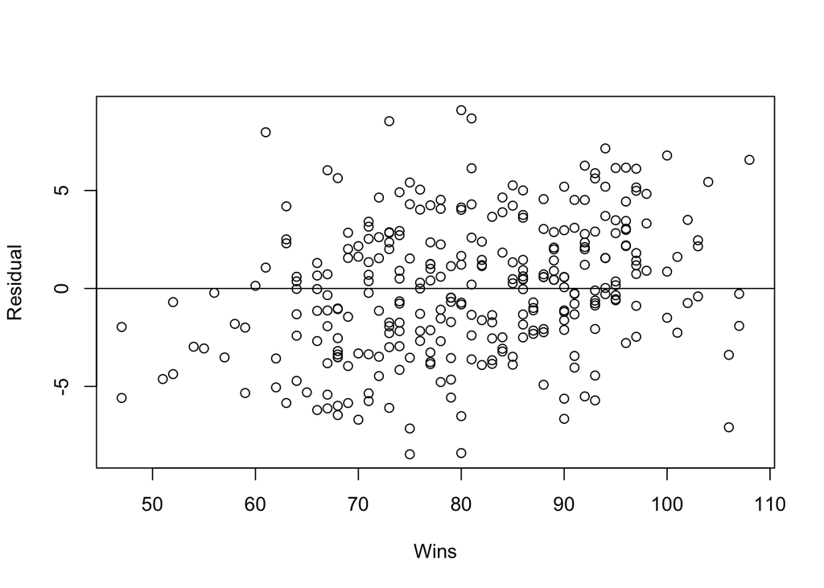

```r
baseball10years$Residuals = residuals(modelfinal10)
plot(baseball10years$W, baseball10years$Residuals, xlab = "Wins", ylab = "Residual")
abline(a=0, b=0)
```

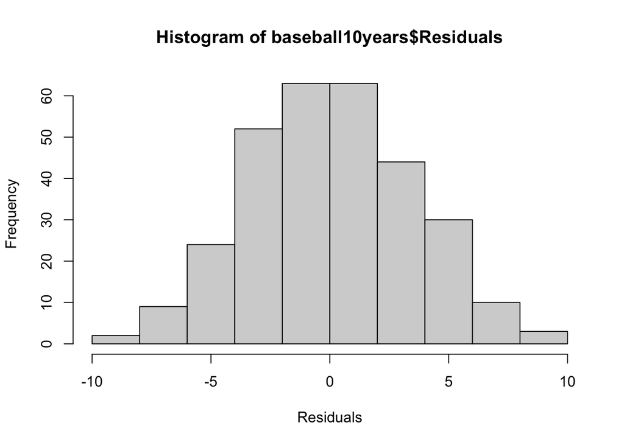

```r
hist(baseball10years$Residuals, xlab = "Residuals")
```

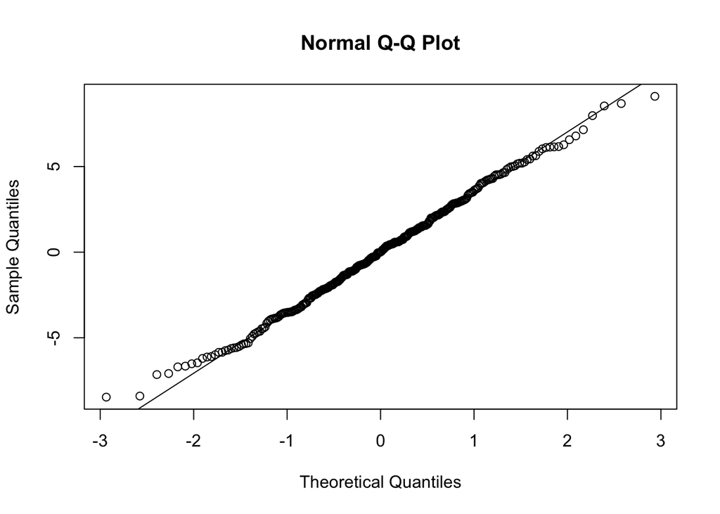

```r
qqnorm(baseball10years$Residuals)
qqline(baseball10years$Residuals)
```